# Introduction to R

Thomas Carroll, Sanjay Khadayate  
Februrary 8th

### Overview

- Background to R
- Data-types in R
- Reading and writing data in R.
- Plotting in R.
- Statistics in R

### What is R?

**R** is scripting language and environment for **statistical computing**.

Developed by [Robert Gentleman](http://www.gene.com/scientists/our-scientists/robert-gentleman) and [Ross Ihaka](https://www.stat.auckland.ac.nz/%7Eihaka/).

Inheriting much from its predecessor **S** (Bell labs).

- Open source & cross platform
- Suited to high level data analysis
- Extensive graphics capabilities
- Diverse range of add-on packages
- Active community of developers
- Thorough documentation

### What is R to you?

**R** comes with excellent “out-of-box” statistical and plotting capabilities.

**R** provides access to 1000s of packages ([CRAN](http://cran.r-project.org/)/[MRAN](http://mran.revolutionanalytics.com/)/[R-forge](https://r-forge.r-project.org/)) which extend the basic functionality of R while maintaining high quality documentation.

In particular, [Robert Gentleman](http://www.gene.com/scientists/our-scientists/robert-gentleman) developed the **[Bioconductor](http://bioconductor.org/)** project where 100's of packages are directly related to Biology and analysis of associated high-throughput experiments.

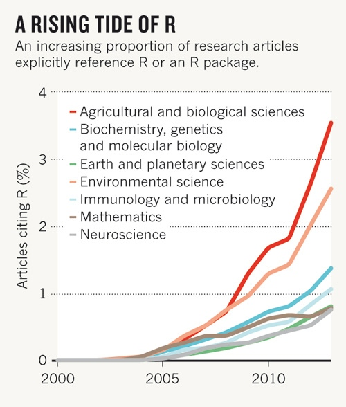

### How to get R?

Freely available from [R-project website](http://cran.ma.imperial.ac.uk/).

RStudio provides an integrated development environment (IDE) which is freely available from [RStudio site](http://www.rstudio.com/)

*We will be using RStudio and R already installed on your machines.*

[figure not shown]

[figure not shown]

### A quick tour of RStudio

Four main panels

- Scripting panel
- R interface
- Environment and History
- Files, directories and help

**Let's load RStudio and take a look**

[figure not shown]

## Data in R

- Simple Calculations
- Variables
- Vectors
- Lists
- Matrices
- Data frames

### Simple Calculations

At its most basic, **R** can be used as a simple calculator.

```r
> 3+1
```

```
[1] 4
```

```r
> 2*2
```

```
[1] 4
```

```r
> sqrt(25)-1
```

```
[1] 4
```

### Using functions.

The **sqrt(25)** demostrates the use of functions in R.

A function performs a complex operation on it's arguments and returns the result.

In R, arguments are provided to a function within the parenthesis – **()** – that follows the function name.

So **sqrt(*ARGUMENT*)** will provide the square root of value of *ARGUMENT*.

Other examples of functions include **mean()**, **sum()**, **max()**. Note multiple arguments are separated by a comma.

```r
mean(2,4,6)
```

```
[1] 2
```

```r
sum(2,4,6)
```

```
[1] 12
```

```r
max(2,4,6)
```

```
[1] 6
```

### Using functions.

R has many useful functions “built in” and ready to use as soon as R is loaded.

An incomplete, illustrative list can be seen [here](http://www.columbia.edu/%7Ecjd11/charles_dimaggio/DIRE/resources/R/rFunctionsList.pdf)

In addition to R standard functions, additional functionality can be loaded into R using libraries. These include specialised tools for areas such as sequence alignment, read counting etc.

If you need to see how a function works try **?** infront of function name.

```r
?sqrt
```

Lets run **?sqrt** in RStudio and look at the help.

### Variables (1/2)

As with other programming languages and even graphical calculators, **R** makes use of **variables**.

A **variable** stores a value as a letter or word.

In **R**, we make use of the assignment operator **<-**

```r
x <- 10
```

Now **x** holds the value of 10

```r
x
```

```
[1] 10
```

### Variables.(2/2)

```r
x
```

```
[1] 10
```

Variables can be altered in place

```r
x <- 20
x
```

```
[1] 20
```

Variables can be used just as the values they contain.

```r
x + sqrt(25)
```

```
[1] 25
```

Variables can be used to create new variables

```r
y <- x + sqrt(25)
y
```

```
[1] 25
```

### Vectors.(1/13)

In **R** the most basic variable or data type is a “Vector”. A vector is an ordered collection of values. The x and y variable we have previously assigned is an example of a vector of length 1.

```r
x
```

```
[1] 20
```

```r
length(x)
```

```
[1] 1
```

To create a multiple value vector we use the function **c()** to *combine* the supplied arguments into one vector.

```r
x <- c(1,2,3,4,5,6,7,8,9,10)
x
```

```
 [1]  1  2  3  4  5  6  7  8  9 10
```

```r
length(x)
```

```
[1] 10
```

### Vectors (2/13).

Vectors of continuous stretches of values can be created by this shortcut.

```r
y <- 6:10
y
```

```
[1]  6  7  8  9 10
```

Another useful function to create stretchs of numeric vectors are seq() and rep() The seq() function creates a sequence of numeric values from a specified start and end value, incrementing by a user defined amount. The rep() function repeats a variable a user-defined number of time

```r
seq(from=1,to=5,by=2)
```

```
[1] 1 3 5
```

```r
rep(c(1,5,10),3)
```

```
[1]  1  5 10  1  5 10  1  5 10
```

### Vectors(3/13) - Indexing

Square brackets **[]** identify the position within a vector (the **index**). These indicies can be used to extract relevant values from vectors.

```r
x
```

```
 [1]  1  2  3  4  5  6  7  8  9 10
```

```r
x[1]
```

```
[1] 1
```

```r
x[8]
```

```
[1] 8
```

### Vectors(4/13) - Indexing

Indicies can be used to extract values from a multiple positions within a vector.

```r
x[c(1,6)]
```

```
[1] 1 6
```

Negative indicies can be used to extract all positions except that specified

```r
x[-5]
```

```
[1]  1  2  3  4  6  7  8  9 10
```

### Vectors(5/13) (indexing)

We can use indicies to modify a specific position in vector

```r
x
```

```
 [1]  1  2  3  4  5  6  7  8  9 10
```

```r
x[5] <- -5
x
```

```
 [1]  1  2  3  4 -5  6  7  8  9 10
```

Indicies can be specified using other vectors.

```r
y
```

```
[1]  6  7  8  9 10
```

```r
x[y] <- 0
x
```

```
 [1]  1  2  3  4 -5  0  0  0  0  0
```

### Remember!

Square brackets **[]** for indexing

```r
x[1]
```

```
[1] 1
```

Parentheses **()** for function argments.

```r
sqrt(4)
```

```
[1] 2
```

### Vectors(6/13) - operations

Vectors in R can be used in arithmetic operations as seen with variables earlier. When a standard arithmetic operation is applied to vector, the operation is applied to each position in a vector.

```r
x <- c(1,2,3,4,5,6,7,8,9,10)
x
```

```
 [1]  1  2  3  4  5  6  7  8  9 10
```

```r
y <- x*2
y
```

```
 [1]  2  4  6  8 10 12 14 16 18 20
```

Multiple vectors can be used within arithmetic operations.

```r
x+y
```

```
 [1]  3  6  9 12 15 18 21 24 27 30
```

### Vectors (7/13) - operations

When applying an arithmetic operation between two vectors of unequal length, the shorter will be recycled.

```r
x+c(1,2)
```

```
 [1]  2  4  4  6  6  8  8 10 10 12
```

```r
x+c(1,2,3)
```

```
 [1]  2  4  6  5  7  9  8 10 12 11
```

### Vectors (8/13) - Character vectors.

So far we have only looked at numeric vectors.

In R we can also create character vectors again using **c()** function. These vectors can be indexed just the same.

```r
y <- c("ICTEM","CommonWealth","Wolfson")
y[2]
```

```
[1] "CommonWealth"
```

Character vectors can be used to assign names to other vectors.

```r
x <- c(1:3)
names(x) <- y
x
```

```
       ICTEM CommonWealth      Wolfson
           1            2            3
```

### Vectors (9/13) - Character vectors.

These named vectors maybe indexed a positions “name”.

```r
x[c("ICTEM","Wolfson")]
```

```
  ICTEM Wolfson
      1       3
```

Index names missing from vectors will return special value “NA”

```r
x[c("Strand")]
```

```
<NA>
  NA
```

### A note on NA values

In R, like many languages, when a value in a variable is missing, the value is assigned a **NA** value.

Similarly, when a calculation can not be perfomed, R will input a **NaN** value.

- **NA** - Not Available.
- **NaN** - Not A Number.

**NA** values allow for R to handle missing data correctly but requires different handling than standard numeric, character or logical values. We will discuss handling **NA** values later.

### Vectors (10/13). Logical vectors

Logical vectors are a special type of value made up of TRUE/T or FALSE/F

```r
z <- c(T,F,T,F,T,F,T,F,T,F)
# z <-  c(TRUE,FALSE,TRUE,FALSE,TRUE,FALSE,TRUE,FALSE,TRUE,FALSE)
z
```

```
 [1]  TRUE FALSE  TRUE FALSE  TRUE FALSE  TRUE FALSE  TRUE FALSE
```

Logical vectors can be used like an index to specify postions in a vector

```r
x <- 1:10
x[z]
```

```
[1] 1 3 5 7 9
```

### Vectors (11/13). Logical vectors

Numeric vectors may be evaluated to produce logical vectors. This can be very useful when using a logical as an index

Common examples are:

- **==** evaluates as equal.
- **>** and **<** evaluates as greater or less than respectively.
- **>=** and **<=** evaluates as greater than or equal or less than or equal respectively.

```r
x > 5
```

```
 [1] FALSE FALSE FALSE FALSE FALSE  TRUE  TRUE  TRUE  TRUE  TRUE
```

```r
x[x > 5]
```

```
[1]  6  7  8  9 10
```

### Vectors (12/13). Logical vectors continued.

Logical vectors can be used in combination to index vectors. To combine logical vectors we can use some common R operators.

- **&** Requires both logical evaluators to be TRUE
- **|** Requires either logical evaluator to be TRUE.
- **!** Reverses logical operator, so TRUE is FALSE and FALSE is TRUE.

```r
x <- 1:10
!x > 4
```

```
 [1]  TRUE  TRUE  TRUE  TRUE FALSE FALSE FALSE FALSE FALSE FALSE
```

```r
x > 4 & x < 7
```

```
 [1] FALSE FALSE FALSE FALSE  TRUE  TRUE FALSE FALSE FALSE FALSE
```

```r
x > 4 | x < 7
```

```
 [1] TRUE TRUE TRUE TRUE TRUE TRUE TRUE TRUE TRUE TRUE
```

### Vectors (13/13). Logical vectors continued.

Such combinations can allow for complex selection of vector's values.

```r
x <- 1:10
x[x > 4 & x < 7]
```

```
[1] 5 6
```

```r
x[x > 4 & !x < 7]
```

```
[1]  7  8  9 10
```

### Time for an exercise!

- Create a vector called “Counts” containing values 4000,2000,3008,4089,1055
- Name this vector with gene names Pax5, Oct4, Sox2, Med2, Jrd2
- Create a vector called “gene.lengths” with same names but values 2000,200,3000,201.
- Calculate counts per gene length for every gene.
- Identify gene with counts greater than the average.

### Matrices (1/)

In excel we are used to tables.

All progamming languages have a concept of a table. In **R**, the most basic table type is a **Matrix**.

A **Matrix** can be created suing the *matrix()* function specifying the arguments of nrow and ncol specifying the number of rows and columns respectively.

```r
narrowMatrix <- matrix(1:10, nrow=5, ncol=2)
narrowMatrix
```

```
     [,1] [,2]
[1,]    1    6
[2,]    2    7
[3,]    3    8
[4,]    4    9
[5,]    5   10
```

```r
wideMatrix <- matrix(1:10, nrow=2, ncol=5)
wideMatrix
```

```
     [,1] [,2] [,3] [,4] [,5]
[1,]    1    3    5    7    9
[2,]    2    4    6    8   10
```

### Matrices (2/)

To find dimensions of a matrix, the dim() function will provide dimensions as row number and column number while nrow() and ncol() will return just row number and column number respectively.

```r
dim(narrowMatrix)
```

```
[1] 5 2
```

```r
nrow(narrowMatrix)
```

```
[1] 5
```

```r
ncol(narrowMatrix)
```

```
[1] 2
```

### Matrices (3/) (Joining vectors and Matrices)

A Matrix can be created from multiple vectors or other Matrices.

**cbind()** can be used to attach data to a matrix as columns.

```r
x <- 1:10
y <- 11:20
z <- 21:22
newMatrix <- cbind(x,y)
newMatrix
```

```
       x  y
 [1,]  1 11
 [2,]  2 12
 [3,]  3 13
 [4,]  4 14
 [5,]  5 15
 [6,]  6 16
 [7,]  7 17
 [8,]  8 18
 [9,]  9 19
[10,] 10 20
```

**rbind()** functions to bind to a matrix as rows.

```r
newerMatrix <- rbind(newMatrix,z)
newerMatrix
```

```
   x  y
   1 11
   2 12
   3 13
   4 14
   5 15
   6 16
   7 17
   8 18
   9 19
  10 20
z 21 22
```

### Matrices (4/) - Joining vectors and Matrices

When creating a matrix using **cbind()** or **matrix()** from incompatable vectors then shorted vector is recycled.

```r
recycledMatrix1 <- cbind(x,z)
recycledMatrix2 <- matrix(1:10,ncol=5,nrow=3)
```

For **rbind()** function longer vector is clipped.

```r
recycledMatrix3 <- rbind(recycledMatrix1,y)
recycledMatrix3
```

```
   x  z
   1 21
   2 22
   3 21
   4 22
   5 21
   6 22
   7 21
   8 22
   9 21
  10 22
y 11 12
```

### Matrices (5/) - Column names

As with vectors, matrices can be named. For matrices the naming is done by columns and rows using **colnames()** and **rownames()** functions.

```r
namedMatrix <- matrix(1:10,ncol=5,nrow=2)
colnames(namedMatrix) <- paste("Column",1:5,sep="_")
rownames(namedMatrix) <- paste("Row",1:2,sep="_")
namedMatrix
```

```
      Column_1 Column_2 Column_3 Column_4 Column_5
Row_1        1        3        5        7        9
Row_2        2        4        6        8       10
```

Information of matrix names can also be retreived using the same functions.

```r
colnames(namedMatrix)
```

```
[1] "Column_1" "Column_2" "Column_3" "Column_4" "Column_5"
```

```r
rownames(namedMatrix)
```

```
[1] "Row_1" "Row_2"
```

### Matrices (6/) - Indexing

Selecting and replacing portions of a matrix can be done by **indexing** using square brackets **[]** much like for vectors.

When indexing Matrices,two values may be provided within the square brackets separated by a comma to retrieve information on a matrix position.

The first value corresponds to rows and the second to columns.

- *myMatrix[rowOfInterest,columnOfInterest]*

```r
narrowMatrix
```

```
     [,1] [,2]
[1,]    1    6
[2,]    2    7
[3,]    3    8
[4,]    4    9
[5,]    5   10
```

Value of first column, second row

```r
narrowMatrix[2,1]
```

```
[1] 2
```

### Matrices (7/) - Indexing

Similarly, whole rows or columns can be extracted. Single rows and columns will return a vector. When multiple columns or row indices are specified, a matrix is returned.

Values of second column (row index is empty!)

```r
narrowMatrix[,2]
```

```
[1]  6  7  8  9 10
```

Values of third row (column index is empty!)

```r
narrowMatrix[3,]
```

```
[1] 3 8
```

Values of second and third row (column index is empty!)

```r
narrowMatrix[c(2,3),]
```

```
     [,1] [,2]
[1,]    2    7
[2,]    3    8
```

### Matrices (8/) (indexing)

As with vectors, names can be used for indexing when present

```r
colnames(narrowMatrix) <- paste("Column",1:2,sep="_")
rownames(narrowMatrix) <- paste("Row",1:5,sep="_")
narrowMatrix[,"Column_1"]
```

```
Row_1 Row_2 Row_3 Row_4 Row_5
    1     2     3     4     5
```

```r
narrowMatrix["Row_1",]
```

```
Column_1 Column_2
       1        6
```

```r
narrowMatrix[,"Column_1"]
```

```
Row_1 Row_2 Row_3 Row_4 Row_5
    1     2     3     4     5
```

```r
narrowMatrix["Row_1","Column_1"]
```

```
[1] 1
```

### Matrices (9/) (advanced indexing)

As with vectors, Matrices can be subset by logical vectors

```r
narrowMatrix
```

```
      Column_1 Column_2
Row_1        1        6
Row_2        2        7
Row_3        3        8
Row_4        4        9
Row_5        5       10
```

```r
narrowMatrix[,1]
```

```
Row_1 Row_2 Row_3 Row_4 Row_5
    1     2     3     4     5
```

```r
narrowMatrix[,1] < 5
```

```
Row_1 Row_2 Row_3 Row_4 Row_5
 TRUE  TRUE  TRUE  TRUE FALSE
```

```r
narrowMatrix[narrowMatrix[,1] < 5,]
```

```
      Column_1 Column_2
Row_1        1        6
Row_2        2        7
Row_3        3        8
Row_4        4        9
```

### Matrices (10/) - Arithmetic operations.

As with vectors, Matrices can have arithmetic operations applied to cells,rows, columns or the whole matrix

```r
narrowMatrix
```

```
      Column_1 Column_2
Row_1        1        6
Row_2        2        7
Row_3        3        8
Row_4        4        9
Row_5        5       10
```

```r
narrowMatrix[1,1]+2
```

```
[1] 3
```

```r
narrowMatrix[1,]+2
```

```
Column_1 Column_2
       3        8
```

```r
mean(narrowMatrix)
```

```
[1] 5.5
```

### Matrices (10/) - Replacement

As with vectors, Matrices can have their elements replaced

```r
narrowMatrix
```

```
      Column_1 Column_2
Row_1        1        6
Row_2        2        7
Row_3        3        8
Row_4        4        9
Row_5        5       10
```

```r
narrowMatrix[1,1] <- 10
narrowMatrix[,2] <- 1
narrowMatrix
```

```
      Column_1 Column_2
Row_1       10        1
Row_2        2        1
Row_3        3        1
Row_4        4        1
Row_5        5        1
```

### Matrices (11/) (Replacement)

Matrices must be all one type (numeric or character).

Here replacing one value with character will turn numeric matrix to character matrix.

```r
narrowMatrix[,2] *2
```

```
Row_1 Row_2 Row_3 Row_4 Row_5
    2     2     2     2     2
```

```r
narrowMatrix[1,1] <- "Not_A_Number"
narrowMatrix
```

```
      Column_1       Column_2
Row_1 "Not_A_Number" "1"
Row_2 "2"            "1"
Row_3 "3"            "1"
Row_4 "4"            "1"
Row_5 "5"            "1"
```

```r
narrowMatrix[,2] *2
```

```
Error: non-numeric argument to binary operator
```

### Factors (1/6)

A special case of a vector is a **factor**.

Factors are used to store data which may be grouped in categories (categorical data). Specifying data as categorical allows R to properly handle the data and make use of functions specific to categorical data.

To create a factor from a vector we use the **factor()** function.Note that the factor now has an additional component called **“levels”** which identifies all categories within the vector.

```r
vectorExample <- c("male","female","female","female")
factorExample <- factor(vectorExample)
factorExample
```

```
[1] male   female female female
Levels: female male
```

```r
levels(factorExample)
```

```
[1] "female" "male"
```

### Factors (2/6)

An example of the use of levels can be seen from applying the summary() function to the vector and factor examples

```r
summary(vectorExample)
```

```
   Length     Class      Mode
        4 character character
```

```r
summary(factorExample)
```

```
female   male
     3      1
```

### Factors (3/6) - levels

In our factor example the levels have been displayed in an alphabetical order. To adjust the display order of levels in a factor, we can supply the desired display order to **levels** argument in the **factor()** function call.

```r
factorExample <- factor(vectorExample,levels=c("male","female"))
factorExample
```

```
[1] male   female female female
Levels: male female
```

```r
summary(factorExample)
```

```
  male female
     1      3
```

### Factors (4/6) - Nominal factors

In some cases there is no natural order to the categories such that one category is greater than the other (Nominal data). In this case we can see that R is gender neutral.

```r
factorExample <- factor(vectorExample,levels=c("male","female"))
factorExample[1] < factorExample[2]
```

```
[1] NA
```

### Factors (5/6) - Ordinal factors

In other cases there will be a natural ordering to the categories (ordinal data). A factor can be specified to be ordered using the ordered argument in combination with specified levels argument.

```r
factorExample <- factor(c("small","big","big","small"),ordered=TRUE,levels=c("small","big"))
factorExample[1] < factorExample[2]
```

```
[1] TRUE
```

### Factors (6/6) Replacement

Unlike vectors, replacing elements within a factor isn't so easy. While replacing one element with an established level is possible, replacing with a novel element will result in a warning.

```r
factorExample <- factor(c("small","big","big","small"))
factorExample[1] <- c("big")
factorExample
```

```
[1] big   big   big   small
Levels: big small
```

```r
factorExample[1] <- c("huge")
factorExample
```

```
[1] <NA>  big   big   small
Levels: big small
```

To add a new level we can use the levels argument.

```r
levels(factorExample) <- c("big","small","huge")
factorExample[1] <- c("huge")
factorExample
```

```
[1] huge  big   big   small
Levels: big small huge
```

### Data.frames (1/)

We saw that with matrices you can only have one type of data. We tried to create a matrix with a character elelment and the entire matrix became a character.

In practice, we would want to have a table which is a mixture of types (e.g a table with samplenames (character), sampletype (factor) and survival time (numeric))

In R, we make use of the data.frame object which allows us to store different data types in one container. To create a data frame we can simply use the data.frame() function.

```r
patientName <- c("patient1","patient2","patient3","patient4")
patientType <- factor(rep(c("male","female"),2))
survivalTime <- c(1,30,2,20)

dfExample <- data.frame(Name=patientName,Type=patientType,Survival_Time=survivalTime)
dfExample
```

```
      Name   Type Survival_Time
1 patient1   male             1
2 patient2 female            30
3 patient3   male             2
4 patient4 female            20
```

### Data.frames (2/) - Indexing and replacement

Data frames may be indexed just as matrices.

```r
dfExample
```

```
      Name   Type Survival_Time
1 patient1   male             1
2 patient2 female            30
3 patient3   male             2
4 patient4 female            20
```

```r
dfExample[dfExample[,"Survival_Time"] > 10,]
```

```
      Name   Type Survival_Time
2 patient2 female            30
4 patient4 female            20
```

### Data.frames (3/) - Indexing and replacement

Unlike matrices however, certain columns can not be replaced. Numeric columns may have their values replaced but columns with character values may not.This occurs because character vectors are treated as vectors by default.

```r
dfExample[dfExample[,"Survival_Time"] < 10,"Survival_Time"] <- 0
dfExample
```

```
      Name   Type Survival_Time
1 patient1   male             0
2 patient2 female            30
3 patient3   male             0
4 patient4 female            20
```

```r
dfExample[dfExample[,"Survival_Time"] < 10,"Name"] <- "patientX"
dfExample
```

```
      Name   Type Survival_Time
1     <NA>   male             0
2 patient2 female            30
3     <NA>   male             0
4 patient4 female            20
```

### Data.frames (4/) (Advanced indexing)

Unlike matrices, it is possible to index a column by using the “$” symbol.

```r
dfExample <- data.frame(Name=patientName,Type=patientType,Survival_Time=survivalTime)

dfExample$Survival_Time
```

```
[1]  1 30  2 20
```

```r
dfExample[dfExample$Survival_Time < 10,]
```

```
      Name Type Survival_Time
1 patient1 male             1
3 patient3 male             2
```

Using the “$” allows for R to autocomplete your selection and so can speed up coding.

```r
dfExample$Surv
```

```
[1]  1 30  2 20
```

But this will not work..

```r
dfExample[,"Surv"]
```

### Data.frames (Creating new column)

The **$** operator allows for the creation of new columns for a data frame on the fly.

```r
dfExample
```

```
      Name   Type Survival_Time
1 patient1   male             1
2 patient2 female            30
3 patient3   male             2
4 patient4 female            20
```

```r
dfExample$new <- rep("newData",nrow(dfExample))
dfExample
```

```
      Name   Type Survival_Time     new
1 patient1   male             1 newData
2 patient2 female            30 newData
3 patient3   male             2 newData
4 patient4 female            20 newData
```

### Data.frames (5/) (factors)

It is possible to update factors in data.frames just as with standard factorss

```r
dfExample <- data.frame(Name=patientName,Type=patientType,Survival_Time=survivalTime)

levels(dfExample[,"Name"]) <- c(levels(dfExample[,"Name"]) , "patientX")
dfExample[dfExample[,"Survival_Time"] < 10,"Name"] <- "patientX"
dfExample
```

```
      Name   Type Survival_Time
1 patientX   male             1
2 patient2 female            30
3 patientX   male             2
4 patient4 female            20
```

### Data.frames (6/) (Creating data.frames without factors)

If you wish to avoid using factors in data.frames then the **stringsAsFactors** argument to **data.frame()** function should be set to **FALSE**

```r
dfExample <- data.frame(Name=patientName,
                        Type=patientType,
                        Survival_Time=survivalTime,
                        stringsAsFactors = F)

levels(dfExample[,"Name"]) <- c(levels(dfExample[,"Name"]) , "patientX")
dfExample[dfExample[,"Survival_Time"] < 10,"Name"] <- "patientX"
dfExample
```

```
      Name   Type Survival_Time
1 patientX   male             1
2 patient2 female            30
3 patientX   male             2
4 patient4 female            20
```

### Data.frames (Ordering)

A useful function in R is order()

For numeric vectors, order() by default returns the indices of vector in that vector's increasing order. This behaviour can be altered by using the “decreasing” argument passed to order.

```r
testOrder <- c(2,1,3)
testOrder
```

```
[1] 2 1 3
```

```r
testOrder[order(testOrder)]
```

```
[1] 1 2 3
```

```r
testOrder[order(testOrder,decreasing=T)]
```

```
[1] 3 2 1
```

### Data.frames (Ordering with NA values)

When a vector contains NA valuees, these NA values will by default be placed last in ordering indices. This can be controlled by na.last argument.

```r
testOrder <- c(2,1,NA,3)
testOrder[order(testOrder,decreasing=T,na.last=T)]
```

```
[1]  3  2  1 NA
```

```r
testOrder[order(testOrder,decreasing=T,na.last=F)]
```

```
[1] NA  3  2  1
```

### Data.frames (Ordering data.frames)

Since the order argument returns an index of intended order for vector, we can use the order() function to order Data.frames by certain columns

```r
dfExample
```

```
      Name   Type Survival_Time
1 patientX   male             1
2 patient2 female            30
3 patientX   male             2
4 patient4 female            20
```

```r
dfExample[order(dfExample$Surv,decreasing=T),]
```

```
      Name   Type Survival_Time
2 patient2 female            30
4 patient4 female            20
3 patientX   male             2
1 patientX   male             1
```

We can also use order to arrange multiple columns in a data.frame by providing multiple vectors to order() function. Ordering will be performed in order of arguments.

```r
dfExample[order(dfExample$Type,
                dfExample$Survival,
                decreasing=T),]
```

```
      Name   Type Survival_Time
3 patientX   male             2
1 patientX   male             1
2 patient2 female            30
4 patient4 female            20
```

### Data.frames (Merging data frames)

A common operation is to join two data frames by common values in a column.

```r
dfExample <- data.frame(Name=patientName,
                        Type=patientType,
                        Survival_Time=survivalTime)
dfExample
```

```
      Name   Type Survival_Time
1 patient1   male             1
2 patient2 female            30
3 patient3   male             2
4 patient4 female            20
```

```r
dfExample2 <- data.frame(Name=patientName[1:3],
                        height=c(6.1,5.1,5.5))

dfExample2
```

```
      Name height
1 patient1    6.1
2 patient2    5.1
3 patient3    5.5
```

```r
mergedDF <- merge(dfExample,dfExample2,by=1,all=F)
mergedDF
```

```
      Name   Type Survival_Time height
1 patient1   male             1    6.1
2 patient2 female            30    5.1
3 patient3   male             2    5.5
```

### Lists

Lists are the final data-type we will look.

In R, lists provide a general container which may hold any data-type as part of its elements. To create a list we can simply use the list() function with arguments specifying the data we wish to include in the list.

```r
firstElement <- c(1,2,3,4)
secondElement <- matrix(1:10,nrow=2,ncol=5)
thirdElement <- data.frame(colOne=c(1,2,4,5),colTwo=c("One","Two","Three","Four"))
myList <- list(firstElement,secondElement,thirdElement)
myList
```

```
[[1]]
[1] 1 2 3 4

[[2]]
     [,1] [,2] [,3] [,4] [,5]
[1,]    1    3    5    7    9
[2,]    2    4    6    8   10

[[3]]
  colOne colTwo
1      1    One
2      2    Two
3      4  Three
4      5   Four
```

### Lists (Named List)

Just as with vectors, list elements can be assigned names.

```r
myNamedList <- list(First=firstElement,Second=secondElement,Third=thirdElement)
myNamedList
```

```
$First
[1] 1 2 3 4

$Second
     [,1] [,2] [,3] [,4] [,5]
[1,]    1    3    5    7    9
[2,]    2    4    6    8   10

$Third
  colOne colTwo
1      1    One
2      2    Two
3      4  Three
4      5   Four
```

### Lists (Indexing)

List, as with other data types in R can be indexed. In contrast to other types, using “[]” on a list will subset the list to another list of selected indices. To retrieve an element from a list in R , two square brackets “[[]]” must be used.

```r
myList <- list(firstElement,secondElement,thirdElement)
myList[1]
```

```
[[1]]
[1] 1 2 3 4
```

```r
myList[[1]]
```

```
[1] 1 2 3 4
```

As with data.frames, the $ sign may be used to extract elements from a list

```r
myNamedList$First
```

```
[1] 1 2 3 4
```

### Lists (Joining lists)

Again, similar to vectors, Lists can be joined in R using the c() function

```r
myNamedList <- list(First=firstElement,Second=secondElement,Third=thirdElement)
myNamedList <- c(myNamedList,list(fourth=c(4,4)))
myNamedList[c(1,4)]
```

```
$First
[1] 1 2 3 4

$fourth
[1] 4 4
```

### Lists (Joining lists)

Note that we are joining to lists. If we joined a vector to a list, all elements of the vector would become list elements.

```r
myList <- c(myList,c(4,4))
myList
```

```
[[1]]
[1] 1 2 3 4

[[2]]
     [,1] [,2] [,3] [,4] [,5]
[1,]    1    3    5    7    9
[2,]    2    4    6    8   10

[[3]]
  colOne colTwo
1      1    One
2      2    Two
3      4  Three
4      5   Four

[[4]]
[1] 4

[[5]]
[1] 4
```

### Lists (Flattening lists)

Sometimes you will wish to “flatten” out a list. When a list contains compatable objects, i.e. list of all one type, the unlist() function can be used. Note the maintenance of names with their additional sufficies.

```r
myNamedList <- list(First=c(1,2,3),Second=c(2,6,7),Third=c(1,4,7))
myNamedList
```

```
$First
[1] 1 2 3

$Second
[1] 2 6 7

$Third
[1] 1 4 7
```

```r
flatList <- unlist(myNamedList)
flatList
```

```
 First1  First2  First3 Second1 Second2 Second3  Third1  Third2  Third3
      1       2       3       2       6       7       1       4       7
```

### Lists (Flattening lists to matrices)

A common step is to turn a list of standard results into matrix. This can be done in a few steps in R.

```r
myNamedList <- list(First=c(1,2,3),Second=c(2,6,7),Third=c(1,4,7))
flatList <- unlist(myNamedList)
listAsMat <- matrix(flatList,
                    nrow=length(myNamedList),
                    ncol=3,
                    byrow=T,
                    dimnames=list(names(myNamedList)))
listAsMat
```

```
       [,1] [,2] [,3]
First     1    2    3
Second    2    6    7
Third     1    4    7
```